# From clinics to sewers: leveraging environmental surveillance and whole genome sequencing to inform transmission of ESBL-*Escherichia coli* in Switzerland

## 5.6 Multidrug resistance

```r
# Define all relevant classes (clinically relevant + betalactamase)
clinically_relevant_classes <- c(
  "macrolide", "aminoglycosides", "sulfonamides", "diaminopyrimidine",
  "tetracycline", "fluoroquinolones", "phenicol", "lincosamide",
  "streptogramin", "rifamycin", "phosphonicacid", "betalactamase"
)

# Match class names as in arg_class
included_classes <- tolower(clinically_relevant_classes)

# Get all relevant genes
relevant_genes <- arg_class %>%
  filter(antibiotic_class %in% included_classes) %>%
  pull(arg)

# Subset full ARG data to relevant genes
arg_data_mdr <- arg_data %>%
  select(Sample, any_of(relevant_genes))

# Long format and join classes
arg_data_long <- arg_data_mdr %>%
  pivot_longer(-Sample, names_to = "Gene", values_to = "Present") %>%
  filter(!is.na(Present)) %>%
  left_join(arg_class, by = c("Gene" = "arg"))

# Count number of unique drug classes per isolate
mdr_counts <- arg_data_long %>%
  group_by(Sample) %>%
  summarise(`Number of drug classes` = n_distinct(antibiotic_class)) %>%
  ungroup()

# Summarize table
mdr_summary <- mdr_counts %>%
  dplyr::count(`Number of drug classes`, name = "Number of isolates") %>%
  mutate(`Percentage of isolates (%)` = round((`Number of isolates` / nrow(arg_data)) * 100, 1))

# Calculate MDR = 3+ line
mdr_3plus <- mdr_summary %>%
  filter(`Number of drug classes` >= 3) %>%
  summarise(
    `Number of drug classes` = "MDR = 3",
    `Number of isolates` = sum(`Number of isolates`),
    `Percentage of isolates (%)` = round(sum(`Percentage of isolates (%)`), 1)
  )

# Combine final table
mdr_final_table <- bind_rows(
  mdr_summary %>% mutate(`Number of drug classes` = as.character(`Number of drug classes`)),
  mdr_3plus
) %>%
  select(`Number of drug classes`, `Number of isolates`, `Percentage of isolates (%)`)

# Display MDR table with left-aligned caption and white background
mdr_final_table %>%
  kable(
    format = "html",  # use "html" if rendering to HTML instead
    booktabs = TRUE,
    longtable = TRUE,
    caption = "Table S8: Distribution of isolates by number of drug resistance classes. The table shows the number and percentage of isolates resistant to varying numbers of drug classes, based on genes detected from the Comprehensive Antibiotic Resistance Database (CARD, accessed 4th November 2023). Multidrug resistance is abbreviated as “MDR”, and is defined as resistance to three or more classes. Classes considered were: aminoglycosides, β-lactamases, fluoroquinolones, diaminopyrimidines, macrolides, sulfonamides, tetracyclines, phenicols, phosphonic acids, lincosamides, and rifamycins."
  ) %>%
  kable_styling(
    latex_options = c("hold_position", "repeat_header"),
    position = "left",
    full_width = FALSE
  )
```

Table S8: Distribution of isolates by number of drug resistance classes. The table shows the number and percentage of isolates resistant to varying numbers of drug classes, based on genes detected from the Comprehensive Antibiotic Resistance Database (CARD, accessed 4th November 2023). Multidrug resistance is abbreviated as “MDR”, and is defined as resistance to three or more classes. Classes considered were: aminoglycosides, β-lactamases, fluoroquinolones, diaminopyrimidines, macrolides, sulfonamides, tetracyclines, phenicols, phosphonic acids, lincosamides, and rifamycins.

| Number of drug classes | Number of isolates | Percentage of isolates (%) |
| --- | --- | --- |
| 1 | 85 | 11.2 |
| 2 | 94 | 12.3 |
| 3 | 111 | 14.6 |
| 4 | 67 | 8.8 |
| 5 | 116 | 15.2 |
| 6 | 187 | 24.5 |
| 7 | 79 | 10.4 |
| 8 | 18 | 2.4 |
| 9 | 4 | 0.5 |
| MDR = 3 | 582 | 76.4 |

```r
# Optional: save as CSV
#write.csv(mdr_final_table, "./tables/TableS8.csv", row.names = FALSE)
```

## 5.7 ARGs per region and source

### 5.7.1 Assign region to each sample

```r
# Standardize region and source names in sample_metadata
sample_metadata <- sample_metadata %>%
  mutate(
    Region = recode(Region,
      "lémanique" = "Lake Geneva Region",
      "Mittelland" = "Midland",
      "Nordwestschweiz" = "Northwestern Switzerland",
      "Zürich" = "Zurich",
      "Ostschweiz" = "Eastern Switzerland",
      "Zentralschweiz" = "Central Switzerland",
      "Tessin" = "Ticino"
    ),
    Source = ifelse(Source == "livestock", "cattle", Source)
  )

# Merge ARGs per region
args_region <- sample_metadata %>%
  select(Sample, Region, Source) %>%
  left_join(
    arg_data %>%
      mutate(args = rowSums(!is.na(select(., -Sample, -NUM_FOUND)))),
    by = "Sample"
  )
```

### 5.7.2 Statistical tests

This chunk assesses whether the distribution of antibiotic resistance gene (ARG) counts differs between sources (clinics, cattle, wastewater, wildlife) within each Swiss region using a Kruskal-Wallis test. If the test detects significant differences, pairwise comparisons are performed using Dunn’s test. We apply a global Bonferroni correction across all comparisons (i.e., all regions combined), instead of region-specific corrections, to better control for multiple testing given limited sample size within regions.

```r
# Initialize results storage
kw_results <- data.frame(Region = character(),
                         Statistic = numeric(),
                         p.value = numeric(),
                         stringsAsFactors = FALSE)

dunn_results <- data.frame(Region = character(),
                           Comparison = character(),
                           Z = numeric(),
                           p.value = numeric(),
                           p.adjusted = numeric(),
                           stringsAsFactors = FALSE)

# Loop through each region
for (region in unique(args_region$Region)) {
  region_data <- args_region %>% filter(Region == region)
  region_data$Source <- as.factor(region_data$Source)

  if (length(unique(region_data$Source)) > 1) {
    # Kruskal-Wallis test
    kruskal_test <- kruskal.test(args ~ Source, data = region_data)

    kw_results <- bind_rows(kw_results, data.frame(
      Region = region,
      Statistic = kruskal_test$statistic,
      p.value = kruskal_test$p.value
    ))

    # Dunn's test WITHOUT per-region adjustment
    dunn_test <- dunnTest(args ~ Source, data = region_data, method = "none")

    # Extract results and keep unadjusted p-values
    dunn_results <- bind_rows(dunn_results,
      as.data.frame(dunn_test$res) %>%
        mutate(Region = region) %>%
        rename(
          Comparison = Comparison,
          Z = Z,
          p.value = P.unadj
        )
    )
  }
}

# Apply global Bonferroni correction
dunn_results$p.adjusted <- p.adjust(dunn_results$p.value, method = "bonferroni")

# Remove the
dunn_results <- dunn_results[, -which(names(dunn_results) == "P.adj")]

# Format Kruskal-Wallis results
kw_results_formatted <- kw_results %>%
  mutate(
    Region = as.character(Region),
    Statistic = round(Statistic, 2),
    `p-value` = round(p.value, 2)
  ) %>%
  select(Region, Statistic, `p-value`)

# Format Dunn’s results
dunn_results_formatted <- dunn_results %>%
  mutate(
    Region = as.character(Region),
    Comparison = as.character(Comparison),
    Z = round(Z, 2),
    `p-value` = round(p.value, 2),
    `p-adjusted` = round(p.adjusted, 2)
  ) %>%
  select(Region, Comparison, Z, `p-value`, `p-adjusted`)

# Label Kruskal-Wallis results
kw_results_formatted_labeled <- kw_results_formatted %>%
  mutate(Test = "Kruskal-Wallis",
         Comparison = NA,
         Z = NA,
         `p-adjusted` = NA) %>%
  select(Region, Test, Comparison, Z, Statistic, `p-value`, `p-adjusted`)

# Label Dunn’s test results
dunn_results_formatted_labeled <- dunn_results_formatted %>%
  mutate(Test = "Dunn's test",
         Statistic = NA) %>%
  select(Region, Test, Comparison, Z, Statistic, `p-value`, `p-adjusted`)

# Combine into one table
table_s9 <- bind_rows(kw_results_formatted_labeled, dunn_results_formatted_labeled)

# Print table in notebook
table_s9 %>%
  kable(
    format = "html",  # or "html" if rendering to HTML
    longtable = TRUE,
    booktabs = TRUE,
    caption = "Table S9: Statistical analysis of differences in antibiotic resistance genes (ARGs) number among sources within different regions of Switzerland. The first part of the table presents the results of the Kruskal-Wallis test, indicating the chi-square (X²) and p-value for each region: Eastern Switzerland, Midland, Lake Geneva Region, Ticino, and Zurich. The second part of the table shows the results of Dunn’s test with Bonferroni adjustment for pairwise comparisons across all tests, including the Z-score, p-value, and adjusted p-value for each comparison between sources (clinics, cattle, wastewater, and wildlife)."
  ) %>%
  kable_styling(
    latex_options = c("hold_position", "repeat_header"),
    full_width = FALSE,
    position = "center"
  )
```

Table S9: Statistical analysis of differences in antibiotic resistance genes (ARGs) number among sources within different regions of Switzerland. The first part of the table presents the results of the Kruskal-Wallis test, indicating the chi-square (X²) and p-value for each region: Eastern Switzerland, Midland, Lake Geneva Region, Ticino, and Zurich. The second part of the table shows the results of Dunn’s test with Bonferroni adjustment for pairwise comparisons across all tests, including the Z-score, p-value, and adjusted p-value for each comparison between sources (clinics, cattle, wastewater, and wildlife).

|  | Region | Test | Comparison | Z | Statistic | p-value | p-adjusted |
| --- | --- | --- | --- | --- | --- | --- | --- |
| Kruskal-Wallis chi-squared…1 | Eastern Switzerland | Kruskal-Wallis | NA | NA | 0.33 | 0.95 | NA |
| Kruskal-Wallis chi-squared…2 | Lake Geneva Region | Kruskal-Wallis | NA | NA | 0.07 | 0.79 | NA |
| Kruskal-Wallis chi-squared…3 | Ticino | Kruskal-Wallis | NA | NA | 2.89 | 0.24 | NA |
| Kruskal-Wallis chi-squared…4 | Midland | Kruskal-Wallis | NA | NA | 8.44 | 0.04 | NA |
| Kruskal-Wallis chi-squared…5 | Zurich | Kruskal-Wallis | NA | NA | 7.12 | 0.03 | NA |
| …6 | Eastern Switzerland | Dunn’s test | cattle - clinics | 0.35 | NA | 0.73 | 1.00 |
| …7 | Eastern Switzerland | Dunn’s test | cattle - wastewater | 0.46 | NA | 0.64 | 1.00 |
| …8 | Eastern Switzerland | Dunn’s test | clinics - wastewater | 0.25 | NA | 0.80 | 1.00 |
| …9 | Eastern Switzerland | Dunn’s test | cattle - wildlife | 0.08 | NA | 0.94 | 1.00 |
| …10 | Eastern Switzerland | Dunn’s test | clinics - wildlife | -0.24 | NA | 0.81 | 1.00 |
| …11 | Eastern Switzerland | Dunn’s test | wastewater - wildlife | -0.35 | NA | 0.72 | 1.00 |
| …12 | Lake Geneva Region | Dunn’s test | wastewater - wildlife | 0.26 | NA | 0.79 | 1.00 |
| …13 | Ticino | Dunn’s test | clinics - wastewater | 1.00 | NA | 0.32 | 1.00 |
| …14 | Ticino | Dunn’s test | clinics - wildlife | -0.97 | NA | 0.33 | 1.00 |
| …15 | Ticino | Dunn’s test | wastewater - wildlife | -1.47 | NA | 0.14 | 1.00 |
| …16 | Midland | Dunn’s test | cattle - clinics | 0.19 | NA | 0.85 | 1.00 |
| …17 | Midland | Dunn’s test | cattle - wastewater | -0.31 | NA | 0.75 | 1.00 |
| …18 | Midland | Dunn’s test | clinics - wastewater | -1.19 | NA | 0.23 | 1.00 |
| …19 | Midland | Dunn’s test | cattle - wildlife | -2.28 | NA | 0.02 | 0.43 |
| …20 | Midland | Dunn’s test | clinics - wildlife | -2.76 | NA | 0.01 | 0.11 |
| …21 | Midland | Dunn’s test | wastewater - wildlife | -2.42 | NA | 0.02 | 0.30 |
| …22 | Zurich | Dunn’s test | clinics - wastewater | 2.23 | NA | 0.03 | 0.49 |
| …23 | Zurich | Dunn’s test | clinics - wildlife | -0.96 | NA | 0.34 | 1.00 |
| …24 | Zurich | Dunn’s test | wastewater - wildlife | -2.03 | NA | 0.04 | 0.81 |

```r
# Define file path
#output_path <- "./tables/TableS9.csv"

# Open a connection to the file
fileConn <- file(output_path, open = "wt")

# Add header line for Kruskal-Wallis section
writeLines("Kruskal-Wallis test results by region", fileConn)
writeLines("Region,Statistic,p-value", fileConn)
write.table(kw_results_formatted, fileConn, sep = ",", row.names = FALSE, col.names = FALSE, append = TRUE)

# Add blank line
writeLines("\n", fileConn)

# Add header line for Dunn's test section
writeLines("Dunn's pairwise comparisons with global Bonferroni correction", fileConn)
writeLines("Region,Comparison,Z,p-value,p-adjusted", fileConn)
write.table(dunn_results_formatted, fileConn, sep = ",", row.names = FALSE, col.names = FALSE, append = TRUE)

# Close the connection
close(fileConn)
```

### 5.7.3 Plot FigureS3

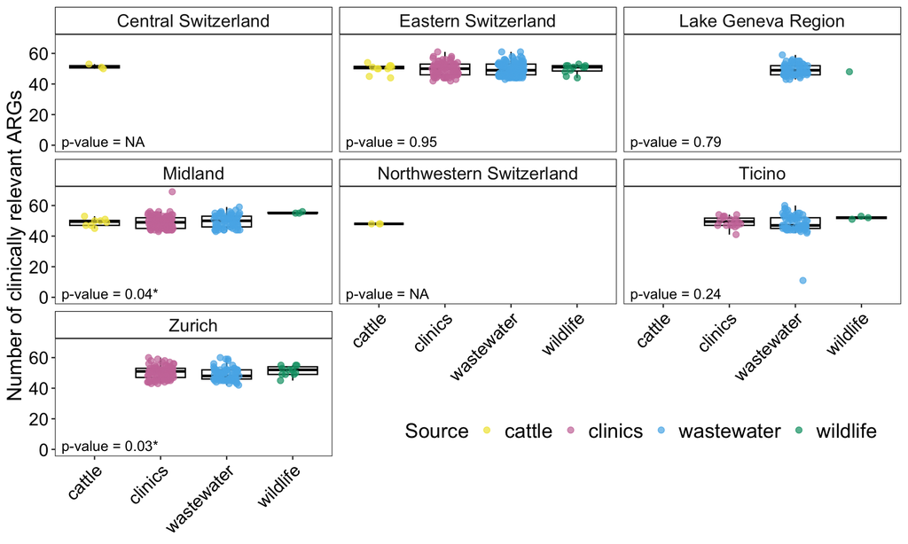

Fig. S3: Regional variation in antibiotic resistance genes (ARGs) distribution across clinical, cattle, wastewater, and wildlife sources in Switzerland. Boxplots show the number of ARGs detected per isolate from clinics (pink), cattle (gold), wildlife (green), and wastewater (blue) across regions of Switzerland. Each panel represents a distinct region, and each boxplot reflects the distribution of ARG counts within a specific source in that region. Only sources with at least three isolates per region are included. P-values from the Kruskal-Wallis test are indicated in the bottom left corner of each panel. Significant differences (p-value < 0.05) are marked with *. When p-value = NA, the test was not performed due to the presence of only one source category in that region.

```r
# Define custom colors
custom_colors_friendly <- c("clinics"= "#CC79A7", "wastewater" ="#56B4E9", "wildlife" ="#009E73", "cattle"="#F0E442")

# Filter data to display boxplot only if there are at least 3 samples
args_region_filtered <- args_region %>%
  group_by(Source, Region) %>%
  filter(n() >= 3)

# Create a label dataframe with Kruskal-Wallis p-values
kw_labels <- kw_results_formatted %>%
  mutate(label = ifelse(`p-value` < 0.05,
                        paste0("p-value = ", `p-value`, "*"),
                        paste0("p-value = ", `p-value`))) %>%
  select(Region, label)

# Join with args_region to retain coordinates
label_coords <- args_region %>%
  group_by(Region) %>%
  summarise(x = 0.5, y = - 1) %>%
  left_join(kw_labels, by = "Region") %>%
  mutate(label = ifelse(is.na(label), "p-value = NA", label))

# Create plot
FigureS3 <- ggplot(args_region, aes(x = Source, y = args, fill = Source)) +
  geom_boxplot(data = args_region_filtered, aes(group = interaction(Source, Region)),
               fill = NA, color = "black", outlier.shape = NA) +
  geom_jitter(aes(color = Source), width = 0.2, height = 0, alpha = 0.7, size=2) +
  scale_color_manual(values = custom_colors_friendly) +
  scale_fill_manual(values = custom_colors_friendly) +
  facet_wrap(~ Region, ncol = 3) +
  labs(
    y = "Number of clinically relevant ARGs",
    x = NULL,
    fill = "Source"
  ) +
  theme_bw() +
  theme(
    axis.text.x = element_text(color = "black", size = 14, angle = 45, hjust = 1),
    axis.text.y = element_text(color = "black", size = 14),
    axis.title = element_text(size = 16, color = "black"),
    strip.text = element_text(size = 14),
    strip.background = element_rect(fill = "white", color = "black"),
    legend.position = c(0.98, 0.02),
    legend.justification = c("right", "bottom"),
    legend.direction = "horizontal",
    legend.text = element_text(size = 16),
    legend.title = element_text(size = 16),
    panel.grid.major = element_blank(),
    panel.grid.minor = element_blank()
  ) +
  geom_text(data = label_coords, aes(x = x, y = y, label = label),
            inherit.aes = FALSE,
            hjust = 0, vjust = 0, size = 4)


print(FigureS3)
```

```r
# save figure
#ggsave("./figures/FigureS3.pdf", plot = FigureS3, width = 11.69, height = 8.27 , units = "in")
```

# 6. Genetic similarity SNPs

## 6.1 Load SNPs data

```r
snps_data <- read.table("distances_no_recomb.tab", header = TRUE, sep = "\t", check.names = FALSE)
```

## 6.2 Format SNP matrix using metadata

```r
# Create a lookup vector from Sample_ID to Sample
name_lookup <- setNames(sample_metadata$Sample, sample_metadata$Sample_ID)

# Extract the matrix from snps_data and set row/column names
distance_matrix <- as.matrix(snps_data[,-1])  # remove first column
rownames(distance_matrix) <- snps_data[[1]]
colnames(distance_matrix) <- snps_data[[1]]

# Rename rows and columns using the lookup
new_names <- name_lookup[rownames(distance_matrix)]

# Check for any unmatched names
if (any(is.na(new_names))) {
  warning("Some Sample_IDs from SNP matrix were not found in sample_metadata!")
}

# Assign new names
rownames(distance_matrix) <- new_names
colnames(distance_matrix) <- new_names
```

## 6.3 Collapse identical sequences from the same sample

Refined logic for defining isolates collected from the “same sample” (per source):

| Source | **Rule for grouping isolates** |
| --- | --- |
| wastewater | Use `Location + Date + Source_detailed` |
| clinics | Each isolate is from a different sample → no grouping |
| cattle | Only group if `Sample` contains a replicate (e.g., `"r"`) |
| wildlife | Only group if `Sample` contains a replicate (e.g., `"r"`) |

```r
# Define Sample_Group using refined rules
sample_metadata <- sample_metadata %>%
  mutate(Sample_Group = case_when(
    Source == "wastewater" ~ paste(Location, Date, Source_detailed, sep = "_"),
    Source %in% c("cattle", "wildlife") & grepl("r", Sample) ~ gsub("r.*", "", Sample),
    TRUE ~ Sample  # for clinical and non-replicate animal isolates
  ))

# Create lookup for sample groups
sample_groups <- sample_metadata$Sample_Group
names(sample_groups) <- sample_metadata$Sample

# Convert SNP matrix to long format and filter identical (0 SNP) pairs
distance_long <- melt(as.matrix(distance_matrix), varnames = c("Isolate1", "Isolate2"), value.name = "SNPs") %>%
  filter(Isolate1 != Isolate2 & SNPs == 0)

# Add group info and keep pairs from same group
identical_pairs <- distance_long %>%
  mutate(Group1 = sample_groups[Isolate1],
         Group2 = sample_groups[Isolate2]) %>%
  filter(Group1 == Group2)

# Create undirected graph of identical isolate pairs
edges <- identical_pairs[, c("Isolate1", "Isolate2")]
g <- igraph::graph_from_data_frame(edges, directed = FALSE)

# Extract connected components
clusters <- igraph::components(g)

# Choose one representative per group
representative_map <- data.frame(Isolate = names(clusters$membership),
                                 Cluster = clusters$membership) %>%
  group_by(Cluster) %>%
  slice(1) %>%
  ungroup()

# Identify isolates to remove
all_identical_isolates <- names(clusters$membership)
representative_isolates <- representative_map$Isolate
isolates_to_remove <- setdiff(all_identical_isolates, representative_isolates)

#  Optional: collapse the distance matrix
collapsed_isolates <- setdiff(rownames(distance_matrix), isolates_to_remove)
distance_matrix_collapsed <- distance_matrix[collapsed_isolates, collapsed_isolates]

# Create full cluster membership mapping
all_membership <- data.frame(
  Isolate = names(clusters$membership),
  Cluster = clusters$membership,
  stringsAsFactors = FALSE
)

# Map each removed isolate to its retained representative
cluster_map <- left_join(all_membership, representative_map, by = "Cluster", suffix = c("_Original", "_Retained"))

# Filter out retained isolates
TableS14 <- cluster_map %>%
  filter(Isolate_Original != Isolate_Retained) %>%
  rename(Removed_Isolate = Isolate_Original, Retained_Isolate = Isolate_Retained)

# Add metadata (Source and Date)
TableS14 <- TableS14 %>%
  left_join(sample_metadata, by = c("Removed_Isolate" = "Sample")) %>%
  select(Removed_Isolate, Retained_Isolate, Source, Date) %>%
  arrange(Removed_Isolate)

# Clean column names
colnames(TableS14) <- c("Removed Isolate", "Retained Isolate", "Compartment", "Collection Date")

# Display nicely formatted table
TableS14 %>%
  kable(
    format = "html",
    longtable = TRUE,
    booktabs = TRUE,
    caption = "Table S14: Identical ESBL-<i>E. coli</i> isolates (0 SNPs) originating from the same sample and collapsed into a single representative. For each case, the retained isolate is listed alongside the collapsed identical sequences, source compartment, and collection date. This includes, for example, multiple clonal isolates obtained from the same wildlife or livestock fecal sample, or from the same wastewater sample."
  ) %>%
  kable_styling(
    latex_options = c("hold_position", "repeat_header"),
    full_width = FALSE,
    position = "center"
  )
```

Table S14: Identical ESBL-*E. coli* isolates (0 SNPs) originating from the same sample and collapsed into a single representative. For each case, the retained isolate is listed alongside the collapsed identical sequences, source compartment, and collection date. This includes, for example, multiple clonal isolates obtained from the same wildlife or livestock fecal sample, or from the same wastewater sample.

| Removed Isolate | Retained Isolate | Compartment | Collection Date |
| --- | --- | --- | --- |
| 20211116alt2 | 20211116alt4 | wastewater | 16_11_2021 |
| 20211116chu2 | 20211116chu3 | wastewater | 16_11_2021 |
| 20211116lug2 | 20211116lug3 | wastewater | 16_11_2021 |
| 20211123chu1 | 20211123chu4 | wastewater | 23_11_2021 |
| 20220118sen3 | 20220118sen4 | wastewater | 18_01_2022 |
| 20220510chu2 | 20220510chu3 | wastewater | 10_05_2022 |
| 20220607lug1 | 20220607lug7 | wastewater | 07_06_2022 |
| 20220607zur1 | 20220607zur7 | wastewater | 07_06_2022 |
| 20220705alt1 | 20220705alt3 | wastewater | 05_07_2022 |
| 20220705lug7 | 20220705lug6 | wastewater | 05_07_2022 |
| 20220927sen3 | 20220927sen7 | wastewater | 27_09_2022 |
| 20221122sen7 | 20221122sen9 | wastewater | 22_11_2022 |
| 20231029chu1 | 20231029chu4 | wastewater | 29_10_2023 |
| 20231030alt2 | 20231030alt4 | wastewater | 29_10_2023 |
| 20231030sen1 | 20231030sen4 | wastewater | 29_10_2023 |
| 20231031gen3 | 20231031gen4 | wastewater | 29_10_2023 |
| L18r1 | L18r3 | cattle | 04_01_2023 |
| L20r1 | L20r3 | cattle | 14_02_2023 |
| L20r2 | L20r3 | cattle | 14_02_2023 |
| W10r1 | W10r2 | wildlife | 19_03_2023 |
| W10r3 | W10r2 | wildlife | 19_03_2023 |
| W15r1 | W15r2 | wildlife | 01_06_2023 |
| W15r3 | W15r2 | wildlife | 01_06_2023 |
| W1r1 | W1r2 | wildlife | 05_12_2022 |
| W1r3 | W1r2 | wildlife | 05_12_2022 |
| W3r1 | W3r2 | wildlife | 20_01_2023 |
| W3r3 | W3r2 | wildlife | 20_01_2023 |
| W7r1 | W7r2 | wildlife | 20_02_2023 |
| W7r3 | W7r2 | wildlife | 20_02_2023 |
| W8r1 | W8r2 | wildlife | 23_02_2023 |
| W8r3 | W8r2 | wildlife | 23_02_2023 |
| W9r1 | W9r3 | wildlife | 28_02_2023 |
| W9r2 | W9r3 | wildlife | 28_02_2023 |

```r
# Save to file
#write.csv(TableS14, "./tables/TableS14.csv", row.names = FALSE)
```

## 6.4 Count clonal pairs

```r
# Prepare binary matrices for different SNP thresholds
clonal_pairs_0 <- distance_matrix_collapsed == 0
clonal_pairs_1_20 <- distance_matrix_collapsed > 0 & distance_matrix_collapsed <= 20
clonal_pairs_21_100 <- distance_matrix_collapsed > 20 & distance_matrix_collapsed <= 100

# Create compartment vector
compartment_vector <- sample_metadata$Source
names(compartment_vector) <- sample_metadata$Sample
compartment_vector <- compartment_vector[rownames(distance_matrix_collapsed)]

# Function to count clonal pairs
count_clonal_pairs <- function(clonal_matrix, compartments) {
  as.data.frame(as.table(clonal_matrix)) %>%
    filter(!is.na(Freq) & Var1 != Var2 & Freq) %>%
    mutate(
      Sample1 = pmin(as.character(Var1), as.character(Var2)),
      Sample2 = pmax(as.character(Var1), as.character(Var2)),
      Compartment1 = compartments[Sample1],
      Compartment2 = compartments[Sample2],
      Type = ifelse(Compartment1 == Compartment2, "Within", "Between")
    ) %>%
    distinct(Sample1, Sample2, .keep_all = TRUE)
}

# Get clonal pairs for each threshold
df_0 <- count_clonal_pairs(clonal_pairs_0, compartment_vector)
df_1_20 <- count_clonal_pairs(clonal_pairs_1_20, compartment_vector)
df_21_100 <- count_clonal_pairs(clonal_pairs_21_100, compartment_vector)

# Total possible pairs
compute_within_pairs <- function(vec) {
  tab <- table(vec)
  data.frame(
    Compartment = names(tab),
    Possible_Pairs = as.numeric((tab * (tab - 1)) / 2)
  )
}

compute_between_pairs <- function(vec) {
  tab <- table(vec)
  compartments <- names(tab)

  if (length(compartments) < 2) return(data.frame())

  pairs <- t(combn(compartments, 2))

  data.frame(
    Compartment1 = pairs[, 1],
    Compartment2 = pairs[, 2],
    Possible_Pairs = tab[pairs[, 1]] * tab[pairs[, 2]]
  )
}

within_totals <- compute_within_pairs(compartment_vector)
between_totals <- compute_between_pairs(compartment_vector)

# Summary function
summary_counts <- function(df, label) {
  df %>%
    group_by(Type, Compartment1, Compartment2) %>%
    summarise(Pairs = n(), .groups = "drop") %>%
    mutate(SNP_Threshold = label)
}

# Apply summary
summary_all <- bind_rows(
  summary_counts(df_0, "0 SNPs"),
  summary_counts(df_1_20, "1–20 SNPs"),
  summary_counts(df_21_100, "21–100 SNPs")
)

# Total clonal pairs by threshold
total_clonal_pairs <- summary_all %>%
  group_by(SNP_Threshold, Type) %>%
  summarise(Pairs = sum(Pairs), .groups = "drop") %>%
  pivot_wider(names_from = Type, values_from = Pairs)

# Within-compartment proportions
within_props <- summary_all %>%
  filter(Type == "Within") %>%
  left_join(within_totals, by = c("Compartment1" = "Compartment")) %>%
  mutate(Percentage = round(100 * Pairs / Possible_Pairs, 2)) %>%
  select(Compartment = Compartment1, SNP_Threshold, Pairs, Percentage)

# Between-compartment proportions
summary_all_between_fixed <- summary_all %>%
  filter(Type == "Between") %>%
  mutate(
    Comp1 = pmin(Compartment1, Compartment2),
    Comp2 = pmax(Compartment1, Compartment2)
  ) %>%
  group_by(Comp1, Comp2, SNP_Threshold) %>%
  summarise(Pairs = sum(Pairs), .groups = "drop")

between_props <- summary_all_between_fixed %>%
  left_join(between_totals, by = c("Comp1" = "Compartment1", "Comp2" = "Compartment2")) %>%
  mutate(Percentage = round(100 * Pairs / Possible_Pairs.Freq, 4)) %>%
  select(
    Compartment1 = Comp1,
    Compartment2 = Comp2,
    SNP_Threshold,
    Pairs,
    Percentage
  ) %>%
  mutate(SNP_Threshold = factor(SNP_Threshold, levels = c("0 SNPs", "1–20 SNPs", "21–100 SNPs"))) %>%
  arrange(SNP_Threshold, Compartment1, Compartment2)

# Format Table S13a: Total Clonal Pairs (rounded, as character)
TableS13a <- total_clonal_pairs %>%
  mutate(across(where(is.numeric), ~ as.character(round(., 0)))) %>%
  pivot_longer(cols = -SNP_Threshold, names_to = "Comparison", values_to = "Pairs") %>%
  pivot_wider(names_from = SNP_Threshold, values_from = Pairs) %>%
  select(Comparison, `21–100 SNPs`, `1–20 SNPs`, `0 SNPs`)

# Format Table S13b: Within Compartments (rounded, 2 digits or 4 if <0.01)
TableS13b <- within_props %>%
  select(Compartment, SNP_Threshold, Percentage) %>%
  pivot_wider(names_from = SNP_Threshold, values_from = Percentage) %>%
  select(Compartment, `21–100 SNPs`, `1–20 SNPs`, `0 SNPs`) %>%
  mutate(across(-Compartment, ~ ifelse(. < 0.01, format(round(., 4), nsmall = 4), format(round(., 2), nsmall = 2)))) %>%
  rename(Comparison = Compartment)

# Format Table S13c: Between Compartments (rounded, as above)
TableS13c <- between_props %>%
  mutate(Label = ifelse(
    is.na(Percentage), NA,
    ifelse(Percentage < 0.01 & Percentage > 0,
           paste0(format(Percentage, nsmall = 4), " (n=", Pairs, ")"),
           paste0(format(round(Percentage, 2), nsmall = 2), " (n=", Pairs, ")"))
  )) %>%
  select(Compartment1, Compartment2, SNP_Threshold, Label) %>%
  pivot_wider(names_from = SNP_Threshold, values_from = Label) %>%
  mutate(Comparison = paste(Compartment1, Compartment2, sep = " vs ")) %>%
  select(Comparison, `21–100 SNPs`, `1–20 SNPs`, `0 SNPs`)

# Header rows (also character)
header_a <- tibble(
  Comparison = "Number of genetically similar pairs",
  `21–100 SNPs` = "", `1–20 SNPs` = "", `0 SNPs` = ""
)
header_b <- tibble(
  Comparison = "Percentage of genetically similar pairs within compartments (%)",
  `21–100 SNPs` = "", `1–20 SNPs` = "", `0 SNPs` = ""
)
header_c <- tibble(
  Comparison = "Percentage of genetically similar pairs between compartments (%)",
  `21–100 SNPs` = "", `1–20 SNPs` = "", `0 SNPs` = ""
)

# Combine all tables into a single data frame
TableS10 <- bind_rows(
  header_a, TableS13a,
  header_b, TableS13b,
  header_c, TableS13c
)

# Save to file
#write.csv(TableS10, "./tables/TableS10.csv", row.names = FALSE)

# Display as kable
TableS10 %>%
  kable(
    format = "html",
    booktabs = TRUE,
    escape = FALSE,
    caption = "Table S10: Genetically similar <i>Escherichia coli</i> isolate pairs, including extended-spectrum β-lactamase (ESBL)-producing strains, detected within and between compartments across SNP thresholds (0, 1–20, and 21–100 SNPs). The upper section reports total pair counts by comparison type (within vs. between). The middle and lower sections show the percentage and count (n) of genetically similar pairs within and between compartments, respectively. Percentages are calculated relative to the total number of possible isolate pairs within or between the corresponding compartments. Analysis was performed in R (v4.1.1)."
  ) %>%
  kable_styling(full_width = FALSE, position = "center") %>%
  row_spec(which(TableS10$Comparison %in% c(
    "Number of genetically similar pairs",
    "Percentage of genetically similar pairs within compartments (%)",
    "Percentage of genetically similar pairs between compartments (%)"
  )), bold = TRUE, background = "#f0f0f0")
```

| Comparison | 21–100 SNPs | 1–20 SNPs | 0 SNPs |
| --- | --- | --- | --- |
| Number of genetically similar pairs |  |  |  |
| Between | 5318 | 1841 | 2 |
| Within | 5272 | 2050 | 39 |
| Percentage of genetically similar pairs within compartments (%) |  |  |  |
| cattle | 1.30 | 4.33 | 0.43 |
| clinics | 7.69 | 2.50 | 0.07 |
| wastewater | 2.33 | 1.19 | 0.01 |
| wildlife | 2.86 | 2.86 | 0.95 |
| Percentage of genetically similar pairs between compartments (%) |  |  |  |
| clinics vs wastewater | 4.32 (n=5087) | 1.54 (n=1816) | 0.0017 (n=2) |
| cattle vs wastewater | 0.38 (n=33) | 0.04 (n=3) | NA |
| clinics vs wildlife | 1.88 (n=85) | 0.22 (n=10) | NA |
| wastewater vs wildlife | 1.44 (n=84) | 0.21 (n=12) | NA |
| cattle vs clinics | 0.44 (n=29) | NA | NA |